# TraCESahulMisc: Workflow Vignette

# Introduction

This vignette provides a worked example using `TraCESahulMisc` to load downscaled TraCE–Sahul climate data, summarise it in time, calculate BIOCLIM variables, match palaeo-observations, generate background points, and fit a quick Random Forest model to examine habitat suitability through time.

# Installing and loading packages

For the vignette we need three packages.

```r
library(TraCESahulMisc)
library(terra)
library(randomForest)
```

```r
# only for plotting
library(rnaturalearth)
conts <- vect(rnaturalearth::ne_coastline(scale = 50))
conts <- crop(conts, ext(125, 135, -13, -8))
```

# Downloading example data

```r
base_dir <- "D:/TraCE-Sahul"
# download_trace_data(base_dir) # Run once only
```

# Importing TraCE–Sahul data

This small function will read in the downloaded data to an object called `sahul` which will then have names for each of the variables.

```r
vars <- c("pr", "tasmax", "tasmin")

load_tracesahul <- function(base, var) {
  f1 <- file.path(base, var,
                  sprintf("TraCE_22ka_downscaled_%s_decadal_21k_1500CE_biascorr.nc", var))
  f2 <- file.path(base, var,
                  sprintf("TraCE_22ka_downscaled_%s_1500_1990_biascorr.nc", var))
  import_TraCESahul(c(f1, f2))
}
sahul <- lapply(vars, function(v) load_tracesahul(base_dir, v))
names(sahul) <- vars
sahul
```

```
#> $pr
#> class       : SpatRaster
#> size        : 100, 200, 31740  (nrow, ncol, nlyr)
#> resolution  : 0.05, 0.05  (x, y)
#> extent      : 125, 135, -13, -8  (xmin, xmax, ymin, ymax)
#> coord. ref. : lon/lat WGS 84 (CRS84) (OGC:CRS84)
#> sources     : TraCE_22ka_downscaled_pr_decadal_21k_1500CE_biascorr.nc  (25860 layers)
#>               TraCE_22ka_downscaled_pr_1500_1990_biascorr.nc  (5880 layers)
#> varnames    : pr (precipitation)
#>               pr (precipitation)
#> names       :       pr_1,       pr_2,       pr_3,       pr_4,       pr_5,       pr_6,        ...
#> unit        : kg m-2 s-1
#> depth       : 1 to 12 (calendar month [calendar month]: 12 steps)
#> time (raw)  : -20045 to 1989 (2645 steps)
#>
#> $tasmax
#> class       : SpatRaster
#> size        : 100, 200, 31740  (nrow, ncol, nlyr)
#> resolution  : 0.05, 0.05  (x, y)
#> extent      : 125, 135, -13, -8  (xmin, xmax, ymin, ymax)
#> coord. ref. : lon/lat WGS 84 (CRS84) (OGC:CRS84)
#> sources     : TraCE_22ka_downscaled_tasmax_decadal_21k_1500CE_biascorr.nc  (25860 layers)
#>               TraCE_22ka_downscaled_tasmax_1500_1990_biascorr.nc  (5880 layers)
#> varnames    : tasmax (Daily Maximum Near-Surface Air Temperatures)
#>               tasmax (Daily Maximum Near-Surface Air Temperatures)
#> names       : tasmax_1, tasmax_2, tasmax_3, tasmax_4, tasmax_5, tasmax_6,     ...
#> unit        : Celcius
#> depth       : 1 to 12 (calendar month [calendar month]: 12 steps)
#> time (raw)  : -20045 to 1989 (2645 steps)
#>
#> $tasmin
#> class       : SpatRaster
#> size        : 100, 200, 31740  (nrow, ncol, nlyr)
#> resolution  : 0.05, 0.05  (x, y)
#> extent      : 125, 135, -13, -8  (xmin, xmax, ymin, ymax)
#> coord. ref. : lon/lat WGS 84 (CRS84) (OGC:CRS84)
#> sources     : TraCE_22ka_downscaled_tasmin_decadal_21k_1500CE_biascorr.nc  (25860 layers)
#>               TraCE_22ka_downscaled_tasmin_1500_1990_biascorr.nc  (5880 layers)
#> varnames    : tasmin (Daily Minimum Near-Surface Air Temperatures)
#>               tasmin (Daily Minimum Near-Surface Air Temperatures)
#> names       : tasmin_1, tasmin_2, tasmin_3, tasmin_4, tasmin_5, tasmin_6,     ...
#> unit        : Celcius
#> depth       : 1 to 12 (calendar month [calendar month]: 12 steps)
#> time (raw)  : -20045 to 1989 (2645 steps)
```

# Temporal summarisation

Here we can use the `summarise_TraCESahul` to aggregate the data in time.

The function is able to summarise an imported TraCESahul SpatRaster to annual, monthly, or seasonal climatologies.

Monthly and seasonal summaries can be taken across the full record or grouped into right-aligned windows of years. When `window = 10`, the pre-1500 data are already decadal climatologies and so are treated accordingly when deriving annual, monthly, or seasonal outputs. The windows are guaranteed not to mix data from before and after 1500 CE as there is a switch from decadal monthly climatologies to annual monthly data from 1500 CE onwards.

Seasonal summaries follow austral seasons. December is treated as belonging to the following year/timestep to ensure correct DJF alignment, including when time steps are spaced irregularly or when windowed summaries are requested.

Below, the imported data is aggregated to monthly averages using a 30-year right aligned window.

```r
pr_monthly_win <- summarise_TraCESahul(sahul$pr, type = "monthly",
                                       sumfun = "mean", window = 30)
tasmax_monthly_win <- summarise_TraCESahul(sahul$tasmax, type = "monthly",
                                           sumfun = "mean", window = 30)
tasmin_monthly_win <- summarise_TraCESahul(sahul$tasmin, type = "monthly",
                                           sumfun = "mean", window = 30)

lyr_names <- rep(month.abb, nlyr(pr_monthly_win)/12)
names(pr_monthly_win) <- paste0(lyr_names, "_pr")
names(tasmax_monthly_win) <- paste0(lyr_names, "_tasmax")
names(tasmin_monthly_win) <- paste0(lyr_names, "_tasmin")
```

# BIOCLIM calculation

The `bioclim_TraCESahul` function calculates bioclimatic variables (BIO1–BIO19) from monthly TraCESahul climate data using `fastbioclim::derive_bioclim`.

The function requires monthly maximum temperature, minimum temperature, and precipitation rasters, performs optional precipitation scaling, processes each year independently, and returns either a list of annual bioclim stacks or collated multi-year rasters for each requested bioclimatic variable.

Ideally, the data should be the output from `summarise_TraCESahul` as there are a number of checks performed on the data, which are guaranteed to pass if the data has been aggregated with `summarise_TraCESahul`.

Precipitation data is automatically converted from a flux (i.e. kg m-2 s-1) to a rate (mm/day) if the units are set. See the `pr_scale` and `new_units` arguments for further details.

Data is automatically saved into a output directory that can be specified. If not specified a `tempdir()` is created and the user is notified of the location of the directory so files can be retrieved.

Optionally, the data can be collated so that each item in the list that is returned is one variable. The alternative `collate = FALSE` results in each item in the list being all the bioclim variables for a given year.

```r
bioclims <- bioclim_TraCESahul(
  tasmax = tasmax_monthly_win,
  tasmin = tasmin_monthly_win,
  pr = pr_monthly_win,
  # store in a folder in basedir. Not recommended
  outdir = paste0(base_dir,"/bioclims"),
  bioclims = c(1, 4, 5, 6, 7, 12, 13, 14, 17, 18), # default is to use 1:19
  collate = TRUE)
bioclims
```

A quick plot shows the first item in the list is all the BIO01 (mean annual temperature) results.

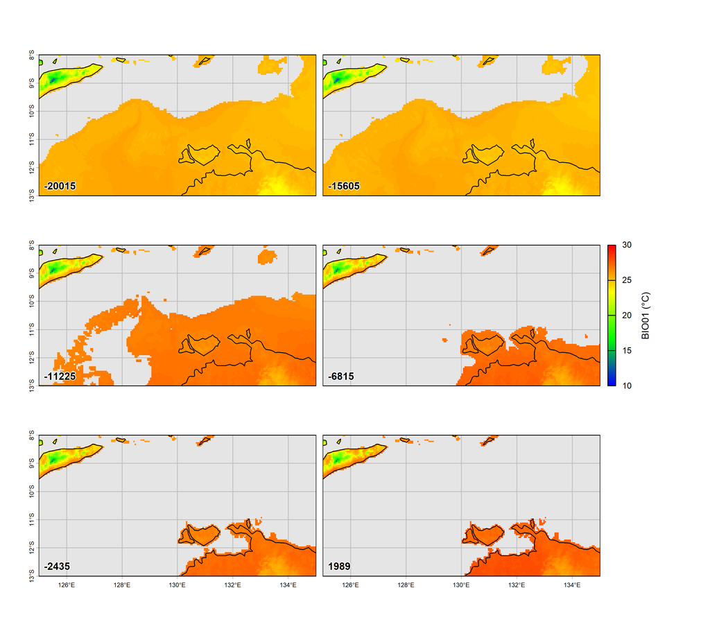

# Generate a mask

Here we generate the mask required by the fossil matching function.

```r
# make a mask using bio01
mask_ras <- bioclims$bio01
mask_ras <- ifel(is.na(mask_ras), NA, 1)
```

# Fossil matching

The example fossil dataset `data(ex_foss)` contains spatial point locations and associated radiocarbon age estimates. The raw object is stored as a SpatVector and needs to be converted into a data table that can be passed to `pair_obs`.

The `terra::unwrap` call ensures that all attributes are pulled into the R session, including the age and confidence interval fields.

To prepare the data, the spatial coordinates are extracted from the SpatVector, unique integer IDs are assigned, and the original date estimate and its upper and lower confidence bounds are retained. The resulting data table contains one row per observation, with explicit latitude, longitude, and temporal uncertainty.

```r
data(ex_foss)
ex_foss <- terra::unwrap(ex_foss)

ex_foss <- data.table::data.table(
  ID = 1:nrow(ex_foss),
  Lat = crds(ex_foss)[,2],
  Lon = crds(ex_foss)[,1],
  Age = ex_foss$date_estimate,
  AgeMin = ex_foss$ci_upper,
  AgeMax = ex_foss$ci_lower
)
```

```
#>       ID     Lat     Lon    Age AgeMin AgeMax
#>    <int>   <num>   <num>  <num>  <num>  <num>
#> 1:     1 -11.575 132.725 -20900 -20859 -20941
#> 2:     2 -12.575 134.275 -20473 -20441 -20505
#> 3:     3 -12.225 133.875 -18041 -17984 -18097
#> 4:     4 -12.525 130.675 -17595 -17551 -17639
#> 5:     5 -12.725 130.475 -17259 -17233 -17285
#> 6:     6 -12.075 133.375 -16878 -16847 -16908
```

The expected input structure for `pair_obs` is a `data.table` containing:

1. Lat and Lon in geographic coordinates (decimal degrees)
2. Age, the central age estimate
3. AgeMin and AgeMax, representing the youngest and oldest bounds of the age range
4. any optional additional columns retained for downstream use

`pair_obs` uses the temporal range (AgeMin–AgeMax) to determine which climate layers should be included during matching.

## Environmental matching with `pair_obs`

`pair_obs` extracts climate values from time-indexed raster stacks and associates them with each fossil record, accounting for temporal uncertainty, spatial neighbourhoods, and optional distance-based filtering. The function is designed specifically for datasets like TraCE–Sahul, where each raster layer corresponds to a single year (or summary period) and a long continuous time series is available.

The matching workflow includes the following steps:

- Identification of candidate climate layers based on fossil ages and the specified temporal window (window). For example, a 30-year window uses the 30 most recent layers preceding the most-recent age estimate (i.e. right aligned).
- Spatial filtering using a mask (mask_layer), which ensures that only land pixels or valid climate surfaces are used. Records occurring on land/sea can be filtered post-matching depending on what is required.
- Extraction of nearby cell values using the requested neighbourhood size (`neigh`). Values may be taken from the closest cell, or averaged across all neighbouring cells if a summary statistic is supplied.
- Optional distance-based exclusion using `dist_cut`, which removes records where the spatial offset between the fossil location and the raster grid exceeds a specified threshold.
- Precision control through the prec argument, which rounds output values.
- Parallelisation using cores for improved performance on large datasets. All rasters are wrapped and unwrapped internally to ensure compatibility with parallel workers. This is currently disabled.

The function returns a data table containing the original fossil metadata, the matched climate values, the temporal layer selected for each match, and diagnostic information about mask status, neighbourhood selection, and any records that could not be matched (e.g. ages older than the available climate layers).

In the following example, climate values are drawn from BIOCLIM rasters (`ras_list = bioclims`). A 30-year right-aligned temporal window is used (`window = 30`), eight-cell neighbourhoods are searched (`neigh = 8`), and values are averaged (`summ_stat = "mean"`) when multiple neighbouring cells are available. Records more than 50 km from the raster grid are excluded (`dist_cut = 50`).

The final output contains matched BIOCLIM variables for all fossils whose ages fall within the time span of the dataset.

```r
foss_matched_bioclim <- pair_obs(
  data = ex_foss,
  ras_list = bioclims,
  mask_layer = mask_ras,
  ras_time = terra::time(bioclims$bio01),
  window = 30, # 30-year window
  neigh = 8, # 8-neighbours (rook)
  prec = 3, # 3 decimal places
  summ_stat = "mean",
  dist_cut = 50, # km
  # parallel is disabled and will be set to 1 if any other value is given
  cores = 1L,
  buff_width = NULL
)
```

```
#> Lon/Lat points will be snapped to nearest points on rasters. Cutoff distance = 50 km.
#> Extracting data from rasters sequentially
#> Warning in pair_obs(data = ex_foss, ras_list = bioclims, mask_layer = mask_ras, :
#> There were 2 samples removed (no temporal match, > cutoff distance, or extraction error).
#> Warning in pair_obs(data = ex_foss, ras_list = bioclims, mask_layer = mask_ras,
#> : Samples removed: 1, 2
```

# Species distribution modelling

Following data aggregation and record matching, we can create a simple species distribution model to examine how habitat suitability (predicted occurence) has changed through time.

Here we use downsampled random forests after extracting some background values through time.

The down-sampling approach for random forests ensures that each tree in the Random Forest is trained using an equal number of presence and background samples. This is controlled through the `sampsize` argument, which accepts a named vector specifying how many observations to draw from each class during bootstrap sampling. Although each tree is fitted with balanced class sizes, the final forest still incorporates the full set of background records because different subsets are selected for each tree across the ensemble.

## Background point generation

Here we generate 12,600 background points (50 samples x 252 timesteps)

```r
# which timesteps from the TraCE-Sahul data are included in our fossil matched data
tidx <- which(terra::time(bioclims$bio01) %in% foss_matched_bioclim$Year)

# extract bg points.
## seed is set for reproducability
{set.seed(84564)
bg_points <- lapply(tidx, function(t) {
  nsamps <- 50
  preds <- rast(lapply(seq_along(bioclims), function(i,...) bioclims[[i]][[t]]))
  names(preds) <- sapply(strsplit(names(preds), "_"), "[", 1)
  data.table::setDT(terra::spatSample(preds, nsamps, na.rm = TRUE))
})}

# collate the sample and round
bg_points <- data.table::rbindlist(bg_points)
cols <- names(bg_points)
bg_points[,(cols) := round(.SD, 3), .SDcols = cols]
```

A quick looks shows what we generated for the first 5 variables

```
#>     bio01   bio04  bio05  bio06  bio07
#>     <num>   <num>  <num>  <num>  <num>
#> 1: 24.970  64.277 27.839 22.126  5.713
#> 2: 25.362  59.277 27.267 23.515  3.753
#> 3: 25.340  59.161 27.158 23.661  3.496
#> 4: 25.333  60.906 27.235 23.503  3.733
#> 5: 25.353 196.556 34.818 16.446 18.372
#> 6: 25.466  68.488 28.073 22.760  5.313
```

## Random Forest modelling

Here we generate the training data and build the random forest.

Columns not needed are excluded, and the presence and absence are set as factors so we can do classification modelling.

```r
training <- data.table::rbindlist(list(
  data.table::copy(foss_matched_bioclim)[, -c("ID", "Lon", "Lat", "Year", "LandSea")][, Occ := "1"],
  data.table::copy(bg_points)[, Occ := "0"]
))

training[, Occ := factor(Occ, levels = c("0","1"))]

prNum <- as.numeric(table(training$Occ)["1"])
spsize <- c("0" = prNum, "1" = prNum)

rf_dws <- randomForest(
  Occ ~ .,
  mtry = 5,
  data = training,
  ntree = 1000,
  importance = TRUE,
  sampsize = spsize,
  replace = TRUE)
```

We can see that the random forest model was moderatly accurate using the misclassification matrix

```
#>
#> Call:
#>  randomForest(formula = Occ ~ ., data = training, mtry = 5, ntree = 1000,      importance = TRUE, sampsize = spsize, replace = TRUE)
#>                Type of random forest: classification
#>                      Number of trees: 1000
#> No. of variables tried at each split: 5
#>
#>         OOB estimate of  error rate: 15.8%
#> Confusion matrix:
#>       0    1 class.error
#> 0 10609 1991   0.1580159
#> 1    48  259   0.1563518
```

## Raster prediction example

Finally, we can predict from the RF model to generate layers of prediction probability (or habitat suitability).

Here we will extract the rasters and predict at a number of timesteps so we can see how probability of occurrence changes through time.

```r
# time steps to extract at
ts <- c(1, 65, 422, 507, 730)

# HS predictions
preds_stack <- rast(lapply(ts, function(t) {
  r <- rast(lapply(seq_along(bioclims), function(i) {
    bioclims[[i]][[t]]
  }))
  # Give the correct names to the layers in each stack
  names(r) <- sapply(strsplit(names(r), "_"), "[", 1)
  # predict prob of occurence
  pr <- predict(r, rf_dws, type = "prob", index = 2)
  names(pr) <- terra::time(bioclims$bio01)[t]
  return(pr)
}))

preds_stack
```

```
#> class       : SpatRaster
#> size        : 100, 200, 5  (nrow, ncol, nlyr)
#> resolution  : 0.05, 0.05  (x, y)
#> extent      : 125, 135, -13, -8  (xmin, xmax, ymin, ymax)
#> coord. ref. : lon/lat WGS 84 (EPSG:4326)
#> source(s)   : memory
#> names       : -20015, -18095, -7385, -4835,  1869
#> min values  :  0.006,  0.000, 0.000, 0.001, 0.002
#> max values  :  0.801,  0.864, 0.931, 0.897, 0.632
```

Now we can get the *true* suitability and add it to our predicted suitability for comparison.

```r
# get the true_suit raster
data(true_suit)
true_suit <- unwrap(true_suit)
names(true_suit) <- "true suitability"

# add the true_suit to the preds_stack
preds_stack <- c(preds_stack, true_suit)
preds_stack
```

```
#> class       : SpatRaster
#> size        : 100, 200, 6  (nrow, ncol, nlyr)
#> resolution  : 0.05, 0.05  (x, y)
#> extent      : 125, 135, -13, -8  (xmin, xmax, ymin, ymax)
#> coord. ref. : lon/lat WGS 84 (EPSG:4326)
#> source(s)   : memory
#> names       : -20015, -18095, -7385, -4835,  1869, true ~ility
#> min values  :  0.006,  0.000, 0.000, 0.001, 0.002,           0
#> max values  :  0.801,  0.864, 0.931, 0.897, 0.632,           1
```

Now we can plot the raster stack of predictions and compare it to the *true* habitat suitability that was used to generate the virtual species occurrences in the `ex_foss` records.

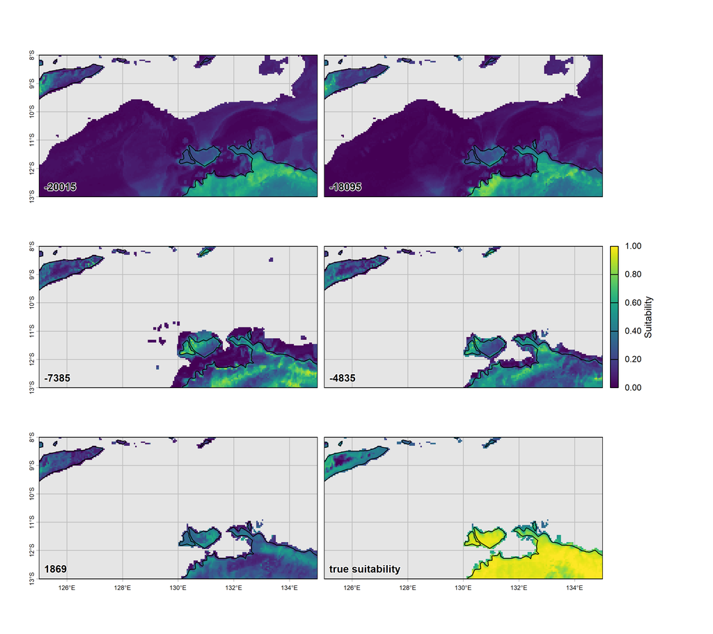

We can see that there are changes in habitat suitability through time. It’s also obvious that the Random Forest SDM is not great at reproducing the *true* suitability of the virtual species, however this is to be expected as the virtual species used a different modelling approach and variables!